# EDA 기말과제

### 평균자책점(p_era)과 사사구율(p_bb_percent)

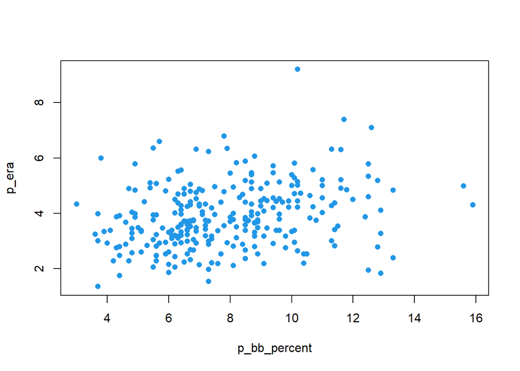

```r
plot(p_era ~ p_bb_percent, mlbp, pch=16, col=4)
```

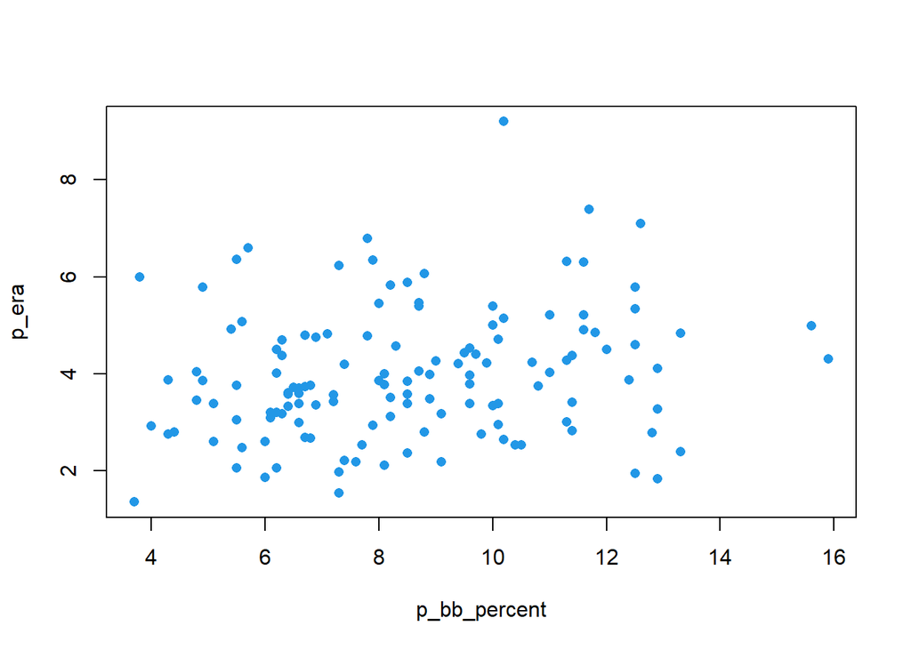

```r
plot(p_era ~ p_bb_percent, mlbp1, pch=16, col=4)
```

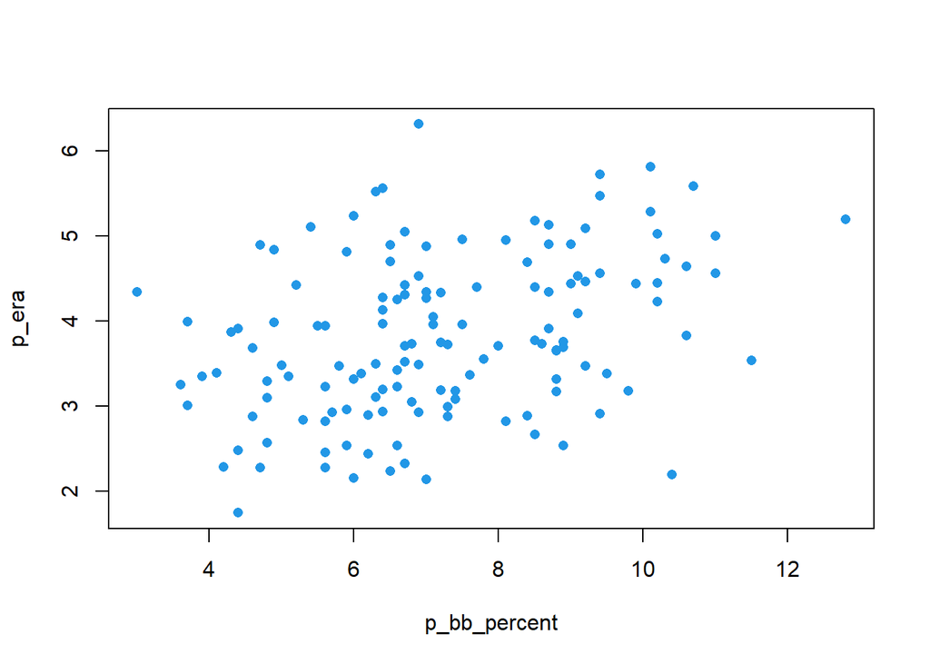

```r
plot(p_era ~ p_bb_percent, mlbp2, pch=16, col=4)
```

사사구율 또한 투수의 제구력과 연관이 있어 실점에 영향을 미칠 것으로 예측했다. 하지만 선발투수와 구원투수로 기준을 나누어 살펴보아도 평균자책점과의 상관관계가 뚜렷하게 보이지 않는다. 따라서, p_bb_percent는 p_era를 결정하는 유의한 변수라고 볼 수 없다.

### 평균자책점(p_era)과 초구스트라이크비율(f_strike_percent)

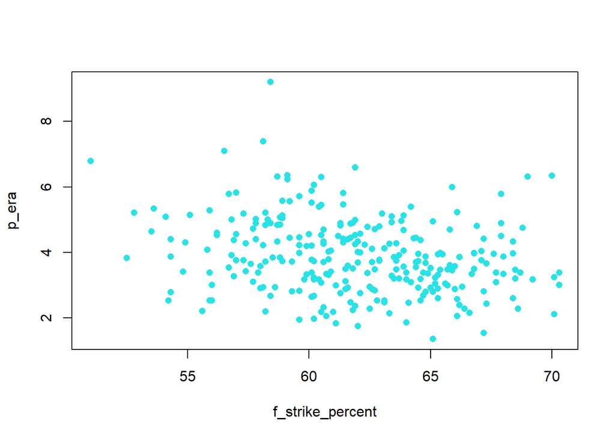

```r
plot(p_era ~ f_strike_percent, mlbp, pch=16, col=5)
```

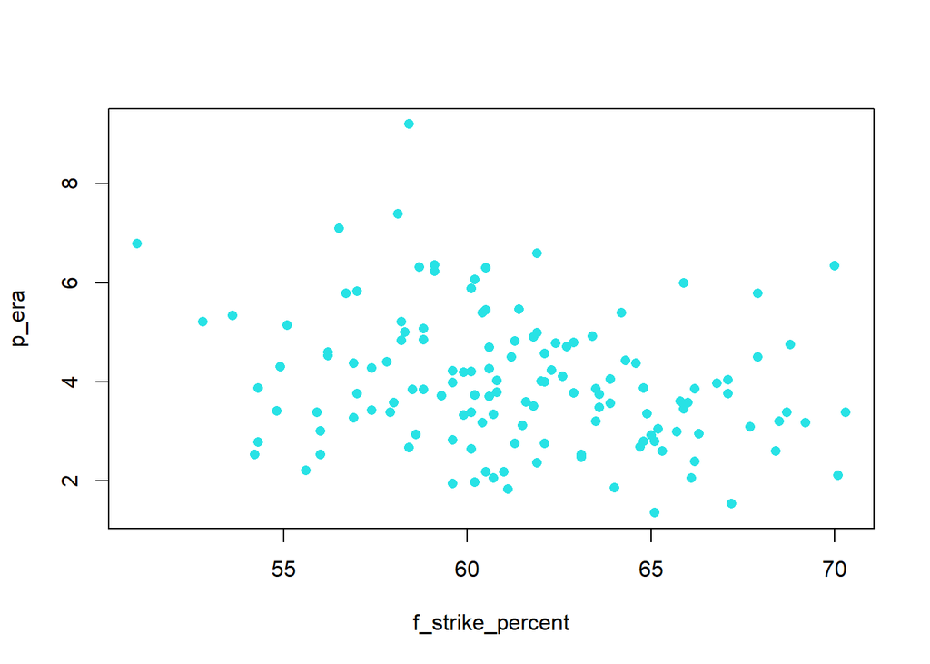

```r
plot(p_era ~ f_strike_percent, mlbp1, pch=16, col=5)
```

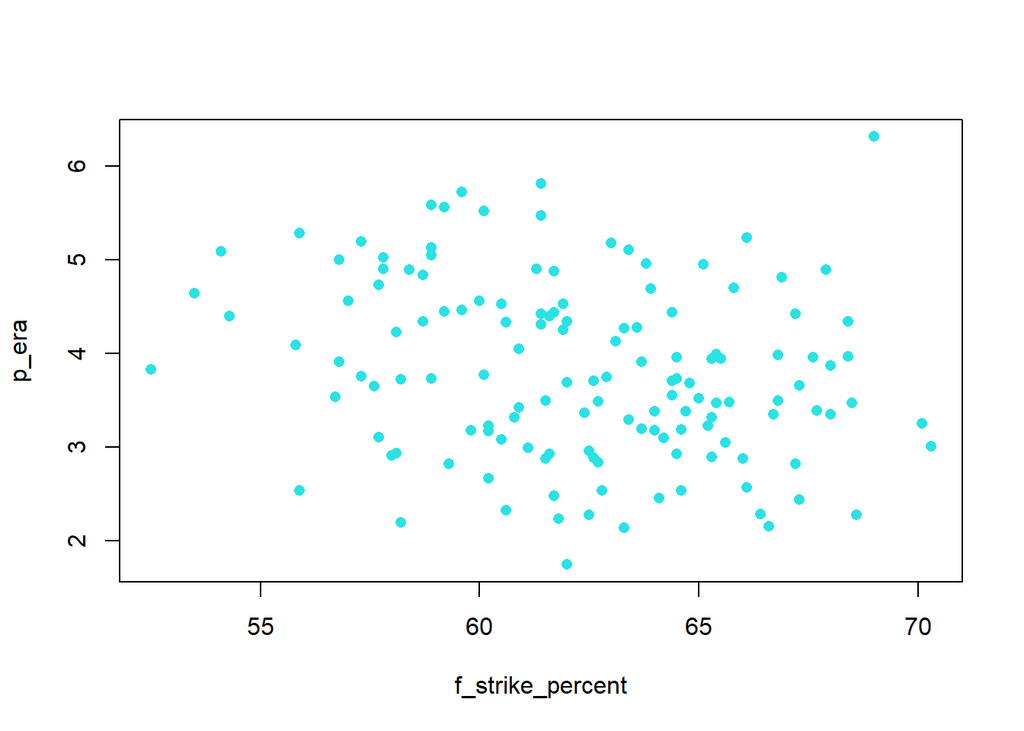

```r
plot(p_era ~ f_strike_percent, mlbp2, pch=16, col=5)
```

초구스트라이크비율을 나타내는 f_strike_percent와 p_era간의 관계를 살펴보면, 모든 구간에서 상관관계가 보이지 않는다. 따라서, f_strike_percent는 p_era에 영향을 주지 않는다고 판단할 수 있다.

### 평균자책점(p_era)과 직구평균구속(fastball_avg_speed)

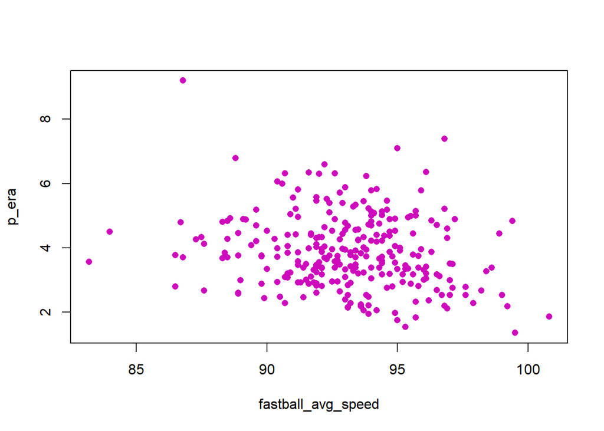

```r
plot(p_era ~ fastball_avg_speed, mlbp, pch=16, col=6)
```

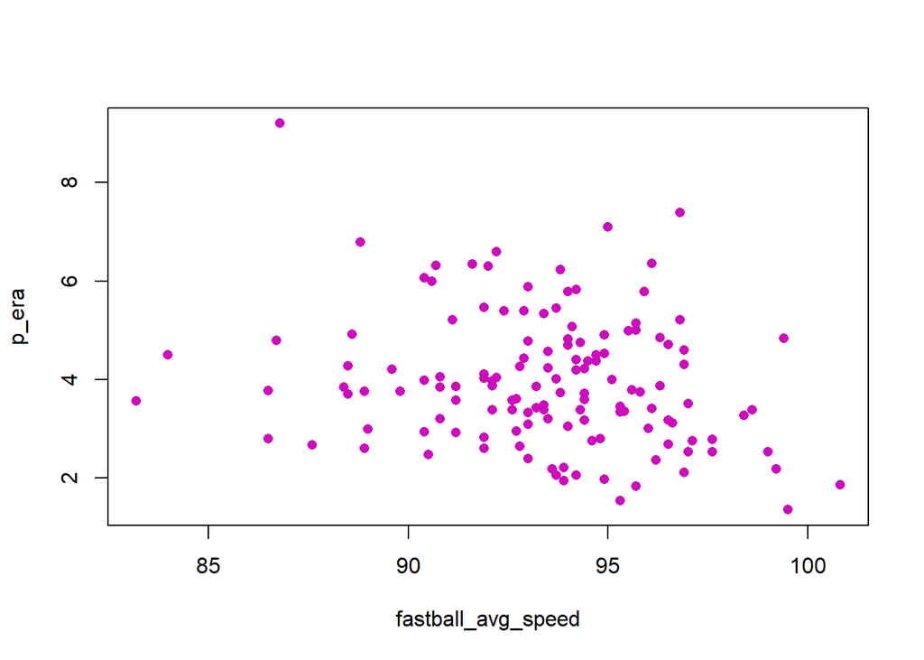

```r
plot(p_era ~ fastball_avg_speed, mlbp1, pch=16, col=6)
```

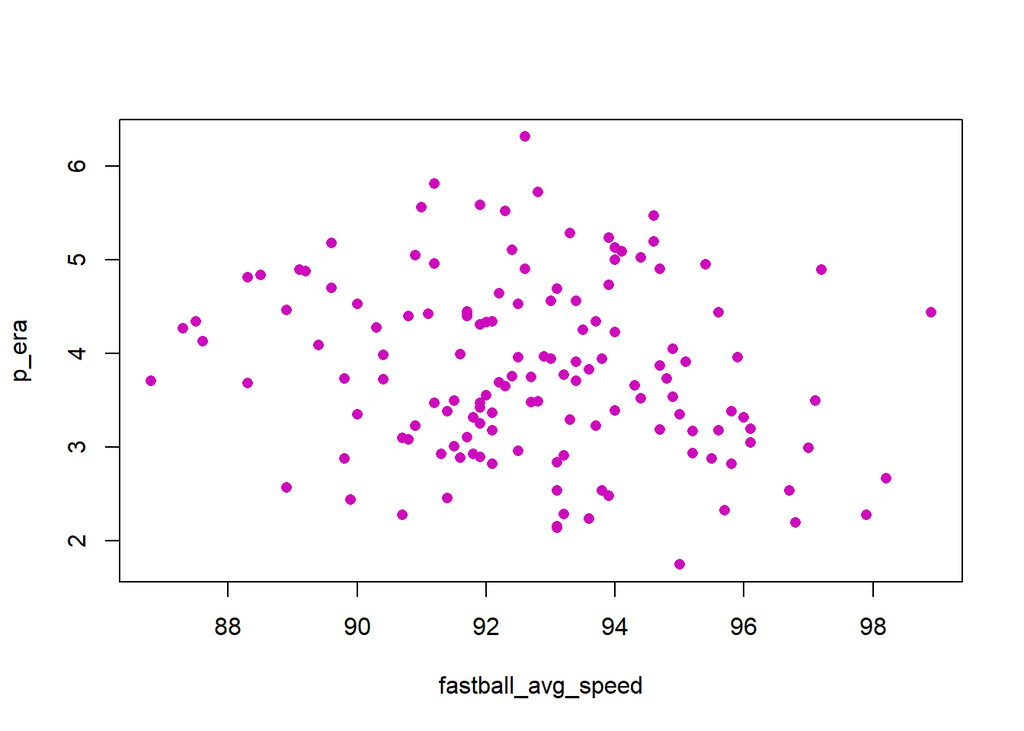

```r
plot(p_era ~ fastball_avg_speed, mlbp2, pch=16, col=6)
```

fastball_avg_speed는 직구계열의 평균 구속을 의미한다. 여기서 직구계열이라 함은 크게 포심패스트볼, 투심패스트볼, 컷패스트볼(커터), 싱킹패스트볼(싱커) 4가지 종류로 나눌 수 있다. 직구의 구속은 통상적으로 투수의 구위와 연관성이 있다고 보는데, 평균 구속이 높다는 것은 그만큼 타자가 공을 맞추기 어려울 가능성이 높다. fastball_avg_speed와 p_era의 관계를 살펴보면, 상관관계가 뚜렷하게 보이지 않는다. 하지만, 평균구속이 높을수록 미세하게 점들이 우하향하는 것처럼 보인다. 따라서 평균구속의 범위를 나누어 추가적으로 분석하고자 한다.

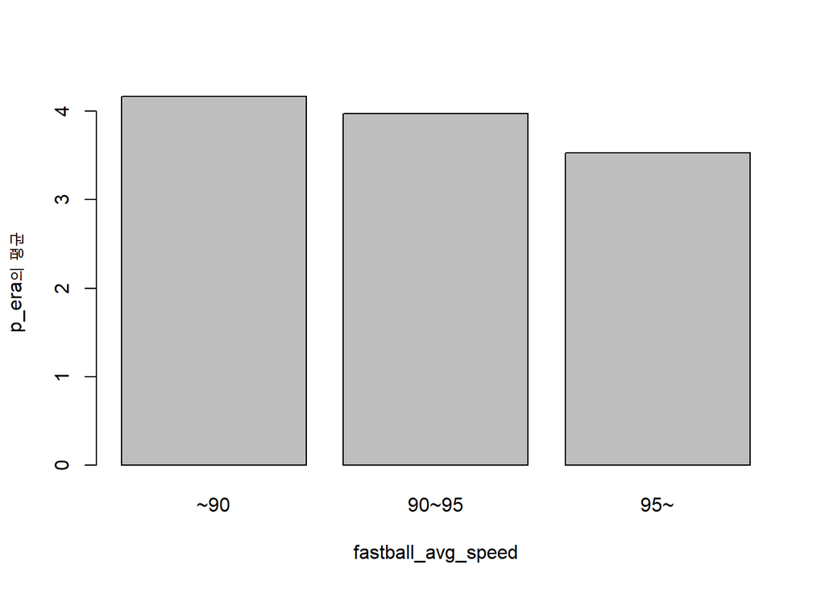

```r
f1 <- mlbp[mlbp$fastball_avg_speed<90,]
f2 <- mlbp[mlbp$fastball_avg_speed>=90 & mlbp$fastball_avg_speed<95, ]
f3 <- mlbp[mlbp$fastball_avg_speed>=95, ]
m_p_era <- c(mean(f1$p_era), mean(f2$p_era), mean(f3$p_era))
barplot(m_p_era, names.arg=c("~90", "90~95", "95~"), xlab="fastball_avg_speed", ylab="p_era의 평균")
```

평균구속을 “90마일 미만”, “90~95마일”, “95마일 이상” 세 그룹으로 나누어 각 그룹의 p_era의 평균을 구해보았다. 그 결과, 평균구속이 높은 그룹의 p_era의 평균이 낮아지는 것을 확인할 수 있다. 첫 번째 plot에서 예측했던 평균구속 증가에 따른 p_era의 미세한 우하향이 어느정도 증명되는 부분이다.

### 평균자책점(p_era)과 변화구평균회전수(breaking_avg_spin)

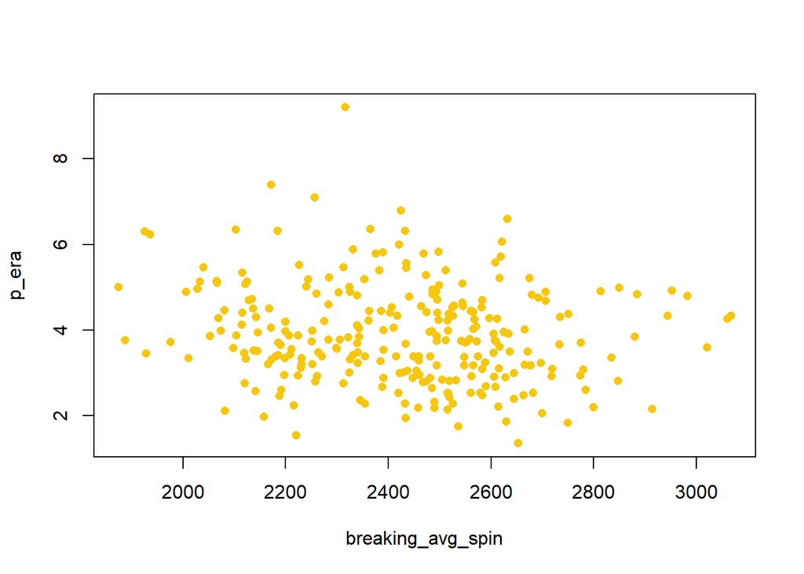

```r
plot(p_era ~ breaking_avg_spin, mlbp, pch=16, col=7)
```

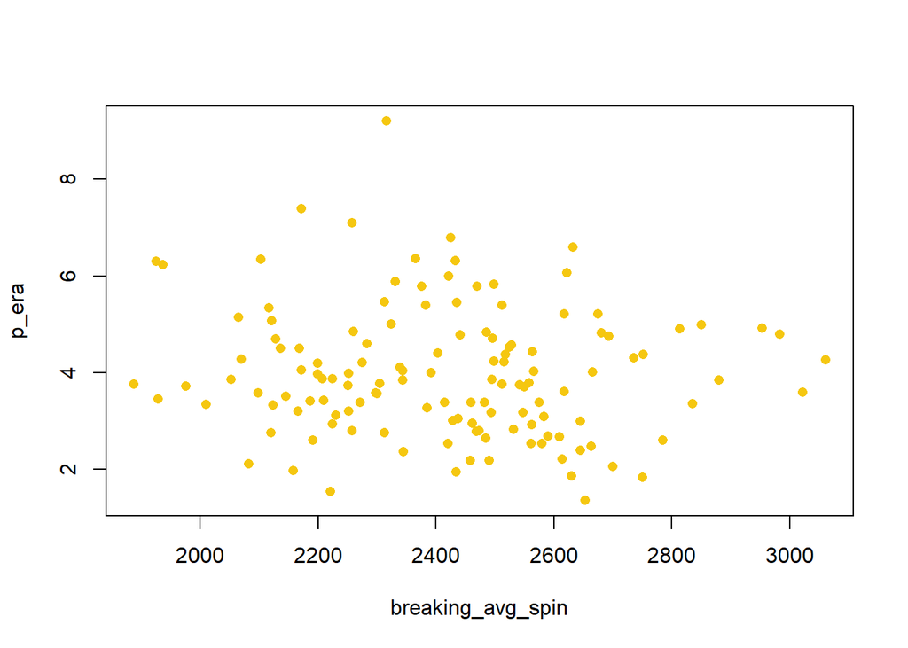

```r
plot(p_era ~ breaking_avg_spin, mlbp1, pch=16, col=7)
```

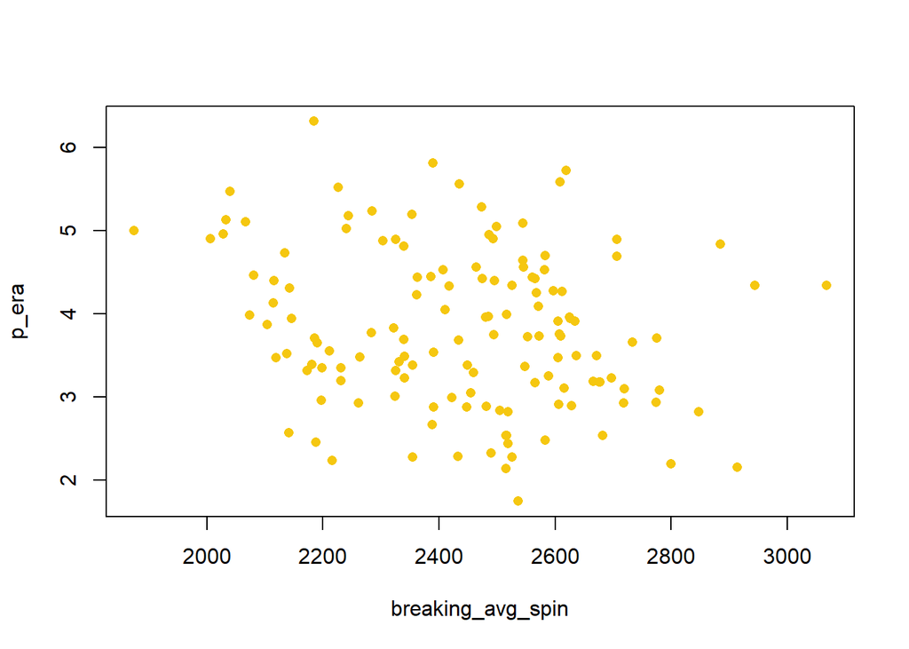

```r
plot(p_era ~ breaking_avg_spin, mlbp2, pch=16, col=7)
```

breaking_avg_spin 변수는 변화구의 평균 회전을 의미한다. 직구와 달리 변화구는 그 종류가 많고, 각각의 변화구마다 속도의 차이가 심해 구속을 기준으로 하지 않았다. 변화구의 회전과 p_era의 관계를 살펴보면, 직구의 구속과 마찬가지로 크게 관계가 없어 보인다.

[figure not shown]

```r
b1 <- mlbp[mlbp$breaking_avg_spin<2200,]
b2 <- mlbp[mlbp$breaking_avg_spin>=2200 & mlbp$breaking_avg_spin<2600, ]
b3 <- mlbp[mlbp$breaking_avg_spin>=2600, ]
m_p_era1 <- c(mean(b1$p_era), mean(b2$p_era), mean(b3$p_era))
barplot(m_p_era, names.arg=c("~2200", "2200~2600", "2600~"), xlab="breaking_avg_spin", ylab="p_era의 평균")
```

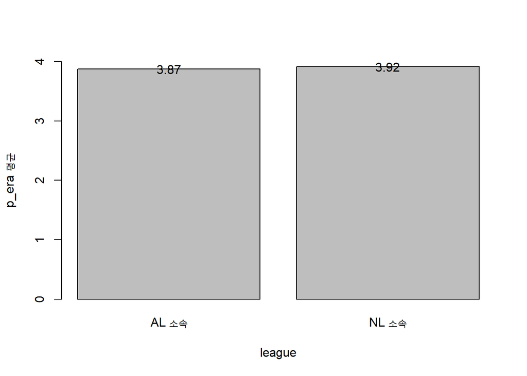

```r
l0 <- mlbp[mlbp$league=="0",]
l1 <- mlbp[mlbp$league=="1",]
l_era <- c(mean(l0$p_era), mean(l1$p_era))
l_name <- c("AL 소속", "NL 소속")
b <- barplot(l_era, names=l_name, ylim=c(0,4), xlab="league", ylab="p_era 평균")
text(b, l_era, labels = round(l_era, 2))
```

league 변수에 따른 p_era의 차이를 알아보기 위해 barplot을 그려보면, AL 소속 투수들의 평균자책점의 평균이 NL 소속 투수들의 평균보다 약 0.05 낮다. 그러나 평균자책점 0.05의 차이에 큰 의미를 두긴 힘들다. 따라서 league와 p_era간의 상관관계는 없다고 판단한다.

### 평균자책점(p_era)과 홀드(p_hold), 세이브(p_save)

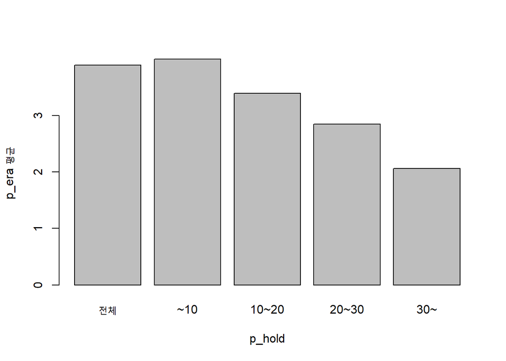

```r
h1 <- mlbp[mlbp$p_hold<=10,]
h2 <- mlbp[mlbp$p_hold>10 & mlbp$p_hold<=20 ,]
h3 <- mlbp[mlbp$p_hold>20 & mlbp$p_hold<=30 ,]
h4 <- mlbp[mlbp$p_hold>30,]
era1 <- mean(mlbp$p_era)
era2 <- mean(h1$p_era)
era3 <- mean(h2$p_era)
era4 <- mean(h3$p_era)
era5 <- mean(h4$p_era)
hold <- c("전체", "~10", "10~20", "20~30", "30~")
eram <- c(era1, era2, era3, era4, era5)
df <- data.frame(hold, eram)
barplot(eram, names=hold, xlab="p_hold", ylab="p_era 평균")
```

p_hold의 수를 10개 단위로 barplot을 그려본 결과 홀드가 10개 이하인 경우 평균자책점이 p_era의 전체 평균보다도 높았지만, 홀드가 늘어날 수록 평균자책점은 낮아지는 것을 확인할 수 있다. 홀드는 구원투수의 주요 수치 중 하나로 홀드가 많다는 것은 그만큼 팀에서 중요한 위치에 있다는 것을 의미한다. 일명 ‘필승조’ 라고 불리는 경우가 많다. 따라서 홀드의 증가는 평균자책점이 낮아지는 데 어느정도는 영향을 미친다고 판단할 수 있다.

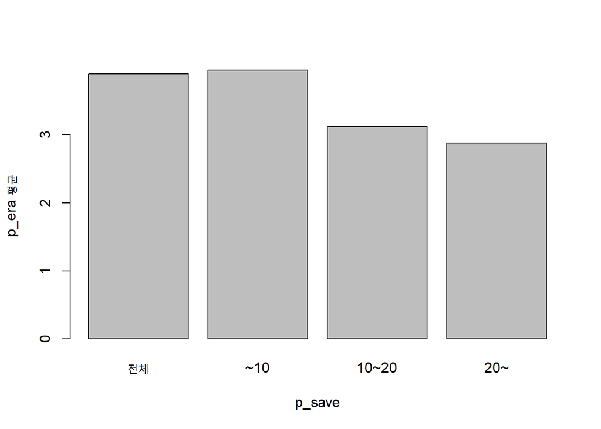

```r
s1 <- mlbp[mlbp$p_save<=10,]
s2 <- mlbp[mlbp$p_save>10 & mlbp$p_save<=20 ,]
s3 <- mlbp[mlbp$p_save>20,]
era1 <- mean(mlbp$p_era)
era7 <- mean(s1$p_era)
era8 <- mean(s2$p_era)
era9 <- mean(s3$p_era)
save <- c("전체", "~10", "10~20", "20~")
eram1 <- c(era1, era7, era8, era9)
df1 <- data.frame(save, eram1)
barplot(eram1, names=save, xlab="p_save", ylab="p_era 평균")
```

p_save도 마찬가지로 세이브 수가 늘어날 수록 미세하지만 p_era가 낮아진다. 한시즌에 20세이브 이상을 기록한 선수는 각 팀의 주전 마무리 투수인 경우가 대부분이다. 따라서 세이브가 많은 투수는 주전 마무리 투수이고, 주전 마무리 투수는 평균자책점이 낮을 확률이 높다.

| #4. 탐색적 자료분석 결과 및 시사점 |
| --- |
| 지금까지의 탐색적 자료분석 결과를 정리하고 앞으로의 통계분석 방향에 내용들을 제시해보시오. |

**answer)**

### p_era와 나머지 변수들의 상관계수

- 지금까지 분석한 내용을 토대로 p_era와 변수들간의 상관계수를 구해 연관이 있다고 판단한 변수들 중에서도 어떤 변수가 가장 상관관계가 강한지 살펴본다. 상관계수는 -1에서 1사이의 값을 가지며, -1에 가까울수록 음의 상관관계, 1에 가까울수록 양의 상관관계, 그리고 0에 가까울수록 선형적인 관계가 없음을 나타낸다.

```r
cor(mlbp[c('p_era','p_total_hits','batting_avg', 'slg_percent')])
```

```
##                  p_era p_total_hits batting_avg slg_percent
## p_era        1.0000000    0.1203822   0.7730746   0.8289995
## p_total_hits 0.1203822    1.0000000   0.3221487   0.2662887
## batting_avg  0.7730746    0.3221487   1.0000000   0.8163657
## slg_percent  0.8289995    0.2662887   0.8163657   1.0000000
```

```r
cor(mlbp1[c('p_era', 'p_total_hits')])
```

```
##                  p_era p_total_hits
## p_era        1.0000000    0.5693052
## p_total_hits 0.5693052    1.0000000
```

위 변수들은 값이 증가할 때, p_era도 같이 증가하는 양의 상관관계를 가지는 변수들이다. p_total hits 변수의 경우 앞서 100이닝 이하를 기록한 구원투수에 대해서만 뚜렷한 상관관계가 나타나는 것으로 확인되어 데이터를 mlbp1으로 변경하였다. 이 중에는 slg_percent 변수의 상관계수가 약 0.83으로 p_era에 가장 큰 영향을 미치는 것으로 확인된다.

```r
cor(mlbp[c('p_era', 'fastball_avg_speed','breaking_avg_spin','p_hold',
'p_save')], use="complete.obs")
```

```
##                         p_era fastball_avg_speed breaking_avg_spin      p_hold      p_save
## p_era               1.0000000        -0.18544911       -0.15566093 -0.24639424 -0.24914893
## fastball_avg_speed -0.1854491         1.00000000        0.01053806  0.19350171  0.30595171
## breaking_avg_spin  -0.1556609         0.01053806        1.00000000  0.05109459  0.09353037
## p_hold             -0.2463942         0.19350171        0.05109459  1.00000000  0.15288682
## p_save             -0.2491489         0.30595171        0.09353037  0.15288682  1.00000000
```

이번에는 p_era와 음의 상관관계를 가지는 변수들의 상관계수를 나타낸 표이다. breaking_avg_spin 데이터에 결측값이 존재해 complete.obs 옵션을 통해 결측값을 제거하고 상관계수를 계산하였다. 음의 상관계수를 가지는 변수들 중에서는 p_hold와 p_save 변수가 약 -0.25로 가장 큰 상관관계를 가진다.

```r
mlbp$league <- as.numeric(mlbp$league)
cor(mlbp[c('p_era','p_formatted_ip','p_bb_percent','f_strike_percent','league')])
```

```
##                        p_era p_formatted_ip p_bb_percent f_strike_percent     league
## p_era             1.00000000    -0.17873976    0.2651442      -0.24140686 0.01865703
## p_formatted_ip   -0.17873976     1.00000000   -0.3686708       0.18516177 0.07135656
## p_bb_percent      0.26514422    -0.36867079    1.0000000      -0.58150367 0.04270650
## f_strike_percent -0.24140686     0.18516177   -0.5815037       1.00000000 0.03808941
## league            0.01865703     0.07135656    0.0427065       0.03808941 1.00000000
```

이 변수들은 앞서 진행한 p_era와의 상관관계 분석에서 뚜렷한 관계가 보이지 않아 연관성이 없다고 판단한 변수들이다. league변수를 제외하면 약하게나마 상관관계가 있다는 결과가 나온다.

### 종합적인 결과

시각화와 상관계수를 통한 p_era와 나머지 변수들의 상관관계를 분석한 죄종결과, slg_percent 변수가 p_era가 높아지는 데 가장 큰 영향을 미쳤다. 즉, 피장타율이 평균자책점 상승의 가장 큰 원인이었다. batting_avg, 피안타율도 만만치않게 p_era에 영향을 미쳤다. 그 외에도 p_total_hits, p_bb_percent가 p_era의 증가와 상관관계가 있었다. 반면, p_hold와 p_save변수는 p_era와 가장 큰 음의 상관관계를 보였으며, fastball_avg_speed, breaking_avg_spin, p_formatted_ip, f_strike_percent 등의 변수도 p_era의 감소에 영향이 있다는 결과가 나왔다. 종합적으로, p_era는 그 값이 작을수록 좋은 지표이다. 따라서 p_era와 양의 상관관계를 가지는 변수는 그 값이 증가할수록 p_era에 부정적인 영향을 미침을 뜻하고, 음의 상관관계를 가지는 변수는 p_era에 긍정적인 영향을 미친다는 의미가 있다. **결국 평균자책점을 낮추기 위해서는 피장타율을 비롯한 피안타율, 피안타 수, 사사구 허용 등을 줄여야 한다. 또한 구원투수에게 주로 해당하는 홀드와 세이브는 많이 기록할수록, 전체적으로는 직구평균구속, 변화구평균회전수, 초구스트라이크비율 등이 높을수록 평균자책점이 낮아질 가능성이 높다.**

### 한계점

**가장 큰 한계점은 한정적인 데이터이다.** 다른 종목도 마찬가지지만 야구라는 스포츠가 1년만 하는 것이 아님에도 불구하고 분석의 원활함을 위해 데이터를 일부만 선택해야 했다. 또한 선택한 1년치의 데이터 안에서도 데이터의 양을 조절하기 위해 규정이닝의 50% 이상의 선수들만을 추렸다. 나아가 p_era와 관련이 있다고 예상되는 변수를 주관적인 기준으로 골라 분석을 진행하였다. 이러한 데이터의 한정적인 부분은 무엇보다도 분석의 정확성을 떨어뜨린다. 앞서 시각화를 통한 분석과 상관계수로 구한 분석의 결과값에 차이가 발생한 것도 데이터의 양이 적었기 때문이었을 것으로 추정된다.

### 보완점 및 향후 분석방향

**우선 데이터의 양을 늘려야한다.** 공식적으로 메이저리그가 시작한 1901년부터 현재까지 수많은 경기기록과 선수들의 데이터가 존재할 것이다. 프로그램이 감당할 수 있는 최대한의 데이터를 활용하는 것이 중요하다. 또한 아무리 세세하고 다양한 기록이 존재하고 생겨난다지만 하나의 변수가 특정상황을 완벽하게 설명하는 것은 불가능하다. **따라서 지금까지의 데이터로 예측모델을 완성했어도 다음, 그다음해의 기록, 상황과 비교하여 끊임없는 피드팩과 수정을 향후 분석방향에 필수적으로 포함시킬 필요가 있다.**